# Exploratory Data Analysis

Matt Motoki

May 31, 2016

# Preprocess the Data

## Load the Data

First we load our data into R.

```r
filepath = "../../Data Files/Subsetted Data/NonProfit/REL/"
# training dataset
train <- fread(paste0(filepath, "kaggle_training_dataset_formatted2.txt"),
               stringsAsFactors = FALSE, drop = c("donated", "amount2", "databaseid"))
```

## Structure of the Data

Next, we take a quick look at the data.

```r
# view a summary of the varables in the dataset
summary(train)
```

```
##    ProjectId      MailId            MailCodeId      prospectid
##  Min.   :16   Min.   : 78797840   Min.   :84579   Min.   :       7
##  1st Qu.:16   1st Qu.: 82604495   1st Qu.:86724   1st Qu.: 2567784
##  Median :16   Median : 84553302   Median :89595   Median :11610802
##  Mean   :16   Mean   : 88473513   Mean   :89397   Mean   :10010181
##  3rd Qu.:16   3rd Qu.: 96012354   3rd Qu.:91883   3rd Qu.:16194397
##  Max.   :16   Max.   :105773259   Max.   :94032   Max.   :26200518
##
##      listid      datemailed            amount               zip
##  Min.   :  25   Length:962082      Min.   :   0.0000   Min.   :  603
##  1st Qu.:  25   Class :character   1st Qu.:   0.0000   1st Qu.:26250
##  Median : 117   Mode  :character   Median :   0.0000   Median :54001
##  Mean   :1480                      Mean   :   0.4052   Mean   :52676
##  3rd Qu.: 259                      3rd Qu.:   0.0000   3rd Qu.:78759
##  Max.   :7231                      Max.   :1500.0000   Max.   :99929
##
##       zip4        packageid        phase
##  Min.   :   0   Min.   : 353   Min.   : 1.000
##  1st Qu.:2012   1st Qu.: 364   1st Qu.: 2.000
##  Median :3514   Median :1316   Median : 3.000
##  Mean   :4147   Mean   :1101   Mean   : 4.687
##  3rd Qu.:5890   3rd Qu.:1512   3rd Qu.: 5.000
##  Max.   :9999   Max.   :1551   Max.   :15.000
##  NA's   :3917
```

Most of the variables are either ids or zipcodes and so the summary statistics (min, mean, max, etc.) are not meaningful. Let’s dive deeper into the analysis.

# Calculating Net Profit

For a fundraising campaign to be successful, the total income from donations must exceed the total cost of sending out the fundraising packages; that is, the net profit should be positive and as large as possible. The total income generated by donations is

```r
sum(train$amount)
```

```
## [1] 389800.7
```

Assuming the cost of sending a package is 29 cents (which is the cost of a stamp in 2012), the baseline net profit that we will try to improve upon is

```r
sum(train$amount - 0.29)
```

```
## [1] 110796.9
```

Ideally, we would like to send packages only to prospects that will donate. The optimal net profit is thus the total profit minus the cost of sending to the donors (and not non-donors) or

```r
with(train, sum(amount[amount>0] - 0.29))
```

```
## [1] 385513.9
```

# Donation Amount

The variable that we are ultimately trying to predict is the amount of a donation. Let us try to gain more insight into this variable.

The average donation amount of an arbitrary package is

```r
mean(train$amount)
```

```
## [1] 0.4051637
```

while the average donation amount among the packages that were successful is

```r
with(train, mean(amount[amount>0]))
```

```
## [1] 26.36995
```

The 10 most frequent donation amounts are

```r
charAmounts <- table(paste0("$", train$amount))
count = sort(charAmounts, decreasing=TRUE)[1:10]
print(data.frame(Amount = names(count), Count = count), row.names=FALSE)
```

```
##  Amount  Count
##      $0 947300
##     $25   2917
##     $10   2717
##     $20   2076
##      $5   1500
##     $50   1181
##     $40    905
##     $15    697
##     $35    658
##      $1    495
```

The large majority of prospects (947300) give nothing. The most common non-zero donation amount is $25 (2917 prospects) followed by $10 (2717 prospects). It also seems that most of the donations are under $100; in fact, the number of donations greater than $100 is

```r
sum(train$amount>100)
```

```
## [1] 181
```

Thus, only 181 or about 0.02% of the prospects donate more than $100. Next, let’s view the number of positive donations less than or equal to $100

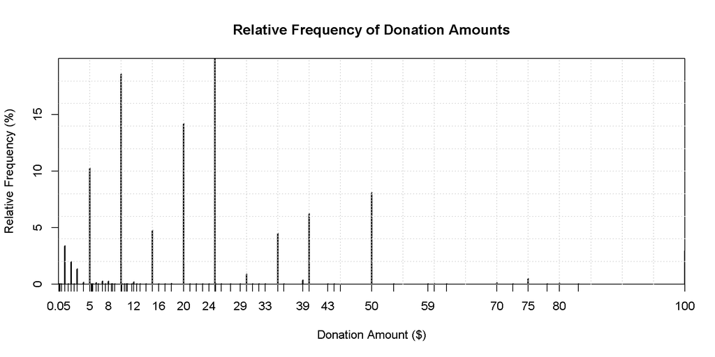

```r
keep <- with(train, amount>0 & amount <= 100)
freq <- table(round(train$amount[keep],2))

plot(freq/sum(freq)*100, xlim = c(0,100),
     xlab = "Donation Amount ($)",
     ylab = "Relative Frequency (%)",
     xaxs="i",yaxs="i",
     main= "Relative Frequency of Donation Amounts")
grid(nx=20,ny=10)
```

## Average Success Rate

Recall that fundraising via mail tends to have a low success rate. For this particular dataset, the overall success rate is

```r
mean(train$amount>0)*100
```

```
## [1] 1.536459
```

Let’s see how success rate relates to a few of the other variables.

```r
formatStr <- function(val, refVal) {
  paste0(sprintf("%0.2f, ", val),
         str_pad(sprintf("(%0.0f%%)", val/refVal*100), 6, pad = " ") )
}


analyzeSuccess <- function(varname) {
  # extract data from training set
  refData <- subset(train, select = c(varname, "amount"))
  names(refData)[1] <- "variable"

  # summarize data
  summaryData <- refData %>% group_by(variable) %>%
    summarize(` Did Not Donate` = sum(amount==0),
              ` Donated` = sum(amount>0),
              ` Success Rate`  = mean(amount>0)*100,
              ` Total Donation Amount` = sum(amount),
              ` Avg. Non-Zero Donation`  = mean(amount[amount>0]),
              ` Expected Donation`  = mean(amount>0)*mean(amount[amount>0])
    )
  names(summaryData)[1] <- varname

  # sort by expected donation
  refVals <- c(sum(train$amount))
  summaryData <- summaryData[order(` Expected Donation`, decreasing = TRUE),]

  refVals <- with(refData, list(sum(amount==0),
                                sum(amount>0),
                                mean(amount>0)*100,
                                sum(amount),
                                mean(amount[amount>0]),
                                mean(amount>0)*mean(amount[amount>0]))
  )
  names(refVals) <- names(summaryData)[-1]

  # format variables
  for (stat in names(summaryData)[-1] ) {
    summaryData[[stat]] <- sapply(summaryData[[stat]], formatStr, refVals[[stat]])
  }

  # print results
  print(paste("The most/least important values of", varname, "are:"))
  print(as.data.frame(summaryData))
}
```

## Success Rate Versus Phase

First, let’s see how success rate relates to the variable phase.

```r
analyzeSuccess("phase")
```

```
## [1] "The most/least important values of phase are:"
##   phase    Did Not Donate         Donated  Success Rate
## 1    14  49259.00,   (5%)  902.00,   (6%)  1.80, (117%)
## 2     6  70922.00,   (7%) 1811.00,  (12%)  2.49, (162%)
## 3     3 193021.00,  (20%) 3297.00,  (22%)  1.68, (109%)
## 4     1 154499.00,  (16%) 2499.00,  (17%)  1.59, (104%)
## 5     2 144790.00,  (15%) 2135.00,  (14%)  1.45,  (95%)
## 6     5  76786.00,   (8%)  748.00,   (5%)  0.96,  (63%)
## 7     4 142159.00,  (15%) 1659.00,  (11%)  1.15,  (75%)
## 8     7  48561.00,   (5%)  892.00,   (6%)  1.80, (117%)
## 9    15  67303.00,   (7%)  839.00,   (6%)  1.23,  (80%)
##    Total Donation Amount  Avg. Non-Zero Donation  Expected Donation
## 1       23279.11,   (6%)           25.81,  (98%)       0.46, (115%)
## 2       33408.80,   (9%)           18.45,  (70%)       0.46, (113%)
## 3       89339.80,  (23%)           27.10, (103%)       0.46, (112%)
## 4       68009.03,  (17%)           27.21, (103%)       0.43, (107%)
## 5       56179.31,  (14%)           26.31, (100%)       0.38,  (94%)
## 6       29312.42,   (8%)           39.19, (149%)       0.38,  (93%)
## 7       54236.94,  (14%)           32.69, (124%)       0.38,  (93%)
## 8       16361.50,   (4%)           18.34,  (70%)       0.33,  (82%)
## 9       19673.75,   (5%)           23.45,  (89%)       0.29,  (71%)
```

According to the results above, the mail sent during the phases 14, 6, and 3 can expect to get about 5 cents more than the average expected donation 41 cents. Moreover, the success rate of these phases are all above average of 1.54%.